# Project Metode Perancangan Percobaan

Sandra Berliana Putri

2024-03-19

#### Import Data

```r
library(readxl)
DataTinggi<-read_xlsx("C:\\Users\\ASUS\\Downloads\\Tugas Kelompok UTS.xlsx")
knitr::kable(DataTinggi)
```

| Varietas | Kelompok | Pupuk | Tinggi |
| --- | --- | --- | --- |
| V1 | 1 | N1 | 3.03 |
| V1 | 2 | N1 | 2.93 |
| V2 | 1 | N1 | 2.67 |
| V2 | 2 | N1 | 2.53 |
| V1 | 1 | N2 | 3.06 |
| V1 | 2 | N2 | 2.93 |
| V2 | 1 | N2 | 2.67 |
| V2 | 2 | N2 | 2.67 |

```r
DataTinggi$Varietas<-as.factor(DataTinggi$Varietas)
DataTinggi$Pupuk<-as.factor(DataTinggi$Pupuk)
DataTinggi$Kelompok<-as.factor(DataTinggi$Kelompok)
AnovaFakRAKL<-aov(Tinggi~Varietas*Pupuk+Kelompok,data=DataTinggi)
summary(AnovaFakRAKL)
```

```
##                Df  Sum Sq Mean Sq F value Pr(>F)
## Varietas        1 0.24851 0.24851 121.473 0.0016 **
## Pupuk           1 0.00361 0.00361   1.766 0.2759
## Kelompok        1 0.01711 0.01711   8.365 0.0629 .
## Varietas:Pupuk  1 0.00151 0.00151   0.739 0.4531
## Residuals       3 0.00614 0.00205
## ---
## Signif. codes:  0 '***' 0.001 '**' 0.01 '*' 0.05 '.' 0.1 ' ' 1
```

```r
qf(0.05,2,28,lower.tail = F)
```

```
## [1] 3.340386
```

```r
qf(0.05,4,28,lower.tail = F)
```

```
## [1] 2.714076
```

```r
qf(0.05,8,28,lower.tail = F)
```

```
## [1] 2.291264
```

#### Plot Interaksi

```r
library(phia)
```

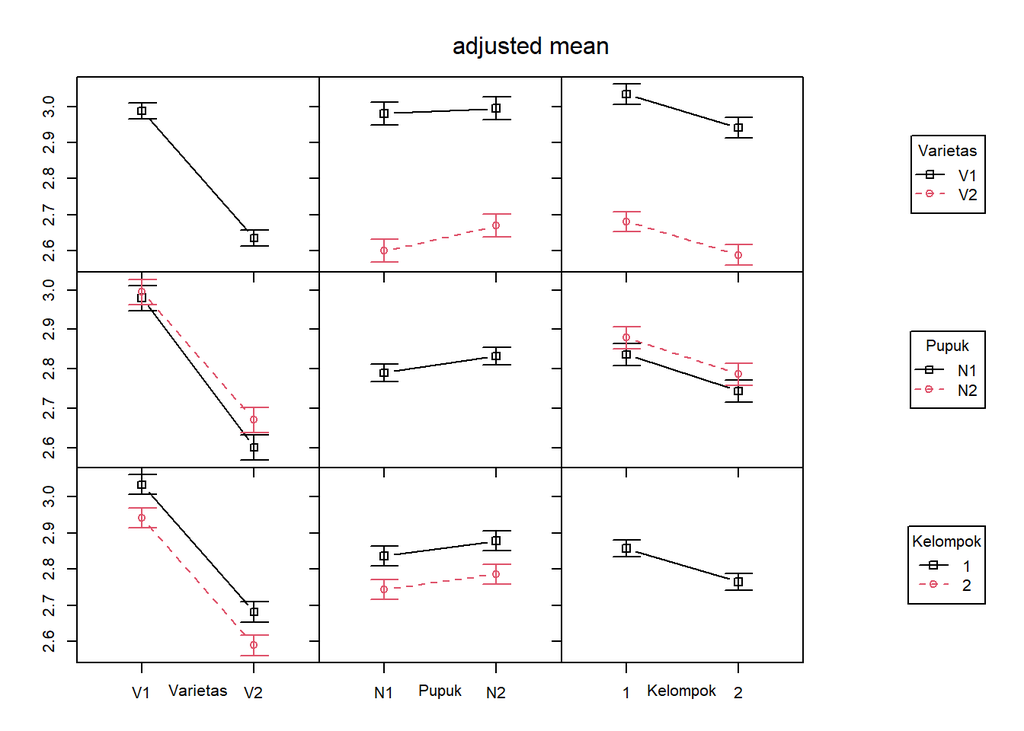

```r
ModelFakRAKL<-lm(Tinggi~Varietas*Pupuk+Kelompok,data=DataTinggi)
im2<-interactionMeans(ModelFakRAKL)
plot(im2)
```

Terlihat pada plot interaksi bahwa tidak ada interaksi pada pengelompokan sesuai yang diharapkan.

#### Import Data

```r
library(readxl)
DatapH<-read_xlsx("C:\\Users\\ASUS\\Downloads\\Tugas Kelompok UTS.xlsx",sheet=2)
knitr::kable(DatapH)
```

| Sitrat | Kelompok | Gula | pH |
| --- | --- | --- | --- |
| 0.5 | 1 | 50 | 3.03 |
| 0.5 | 2 | 50 | 2.93 |
| 1.0 | 1 | 50 | 2.67 |
| 1.0 | 2 | 50 | 2.53 |
| 0.5 | 1 | 70 | 3.06 |
| 0.5 | 2 | 70 | 2.93 |
| 1.0 | 1 | 70 | 2.67 |
| 1.0 | 2 | 70 | 2.67 |

```r
DatapH$Sitrat<-as.factor(DatapH$Sitrat)
DatapH$Gula<-as.factor(DatapH$Gula)
DatapH$Kelompok<-as.factor(DatapH$Kelompok)
AnovaFakRAKL<-aov(pH~Sitrat*Gula+Kelompok,data=DatapH)
summary(AnovaFakRAKL)
```

```
##             Df  Sum Sq Mean Sq F value Pr(>F)
## Sitrat       1 0.24851 0.24851 121.473 0.0016 **
## Gula         1 0.00361 0.00361   1.766 0.2759
## Kelompok     1 0.01711 0.01711   8.365 0.0629 .
## Sitrat:Gula  1 0.00151 0.00151   0.739 0.4531
## Residuals    3 0.00614 0.00205
## ---
## Signif. codes:  0 '***' 0.001 '**' 0.01 '*' 0.05 '.' 0.1 ' ' 1
```

```r
qf(0.05,2,28,lower.tail = F)
```

```
## [1] 3.340386
```

```r
qf(0.05,4,28,lower.tail = F)
```

```
## [1] 2.714076
```

```r
qf(0.05,8,28,lower.tail = F)
```

```
## [1] 2.291264
```

Berdasarkan hasil pengujian dengan ANOVA, diperoleh hasil bahwa: 1. Tolak $H_0$ pada konsentrasi asam sitrat. Terdapat perbedaan pengaruh konsentrasi asam sitrat terhadap pH sirup jeruk pada taraf nyata 5%. 2. Tak Tolak $H_0$ pada konsentrasi gula. Tidak terdapat perbedaan pengaruh konsentrasi gula terhadap pH sirup jeruk pada taraf nyata 5%. 3. Tak tolak $H_0$ pada interaksi konsentrasi asam sitrat dengan konsentrasi gula. Tidak terdapat perbedaan pengaruh konsentrasi asam sitrat dengan konsentrasi gula terhadap pH sirup jeruk pada taraf nyata 5%. 4. Tak tolak $H_0$ pada kelompok. Tidak terdapat perbedaan pengaruh kelompok terhadap pH sirup jeruk pada taraf nyata 5%.

#### Plot Interaksi

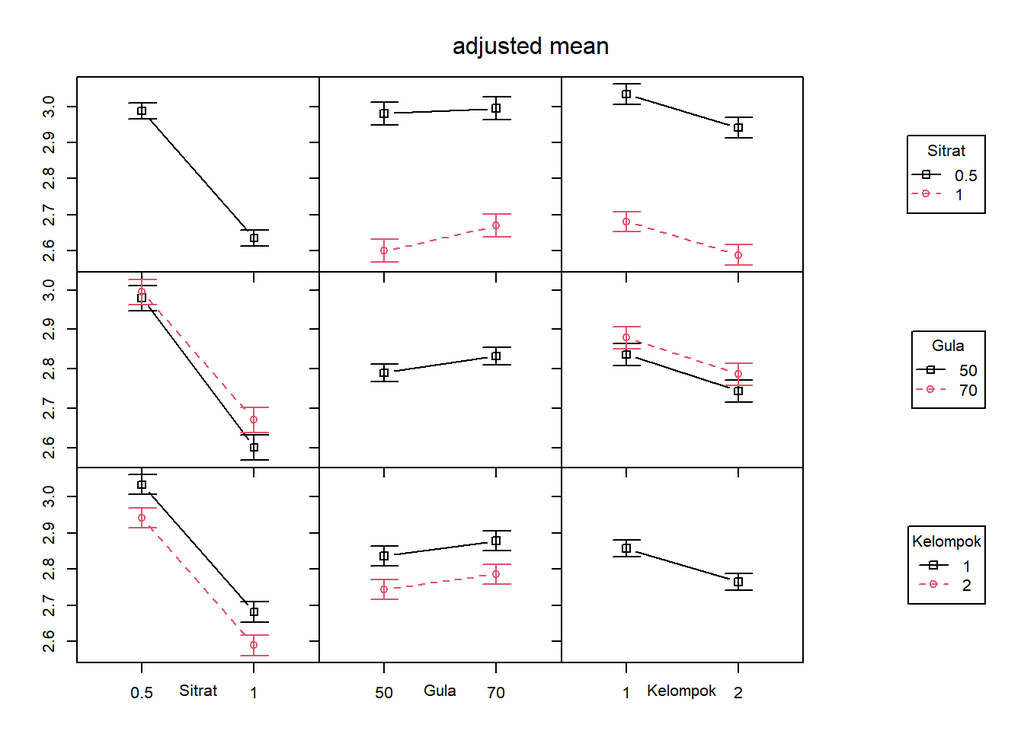

```r
library(phia)
ModelFakRAKL<-lm(pH~Sitrat*Gula+Kelompok,data=DatapH)
im2<-interactionMeans(ModelFakRAKL)
plot(im2)
```

Terlihat pada plot interaksi bahwa tidak ada interaksi pada pengelompokan sesuai yang diharapkan.